# Neuro comorbidity

```r
library(tidyverse)
library(readxl)
library(DT)
library(rcartocolor)
library(gghighlight)

theme_set(theme_bw() +
            theme(legend.title = element_blank(),
                  panel.grid.minor = element_blank()))
for (r_file in list.files('R/', full.names = TRUE)) source(r_file)
```

```r
# demo_raw <- read.csv("../../Phase2.1/Date_Shifted_Files/LocalPatientSummary_Shift.csv")
# obs_raw <- read.csv("../../Phase2.1/LocalPatientObservations.csv")
```

```r
# labs_raw <- read_csv('../thrombotic-penn/data/labs_long_thrombo_v2.csv')
# clin_raw <- read_csv(
#   '../thrombotic-penn/data/LocalPatientClinicalCourseSHIFTED-UPenn.csv',
#   col_types = list(patient_num = col_character()))
demo_raw <- read_csv(
 '../thrombotic-penn/data/LocalPatientSummarySHIFTED-UPenn.csv',
 col_types = list(patient_num = col_character()))
obs_raw <- read_csv(
 '../thrombotic-penn/data/LocalPatientObservations-UPenn.csv',
 col_types = list(patient_num = col_character()))
```

```r
loinc <- read_csv('public-data/penn-loinc-map.csv')
neuro_icds_10 <- read_excel('public-data/2020-09-10_neuro-icd10.xlsx') %>%
  rename('icd' = `ICD-10`)
```

## Data pre-processing

In this initial analysis, we will consider neuro patients as those with a neuro code on the day **of** or **anytime after** their first day of admission.

Only examining ICD-10 for now.

*Note: We will need to discuss whether we want to include codes assigned on the day of admission as comorbidities.*

How do we define “neuro patients”? Patients with prior neurological conditions? Patients who developed neurological conditions after COVID-19 related admission

(using after admission for now…)

The `all_neuro_pats` vector contains neuro patients regardless of whether or not they have a comorbidity/data prior to admission.

```r
n_patients <- nrow(demo_raw)
obs_raw <- obs_raw %>%
  filter(concept_type %in% c("DIAG-ICD10", "DIAG-ICD9"))

all_neuro_pats <- obs_raw %>%
  # filter(days_since_admission >= 0) %>%
  right_join(neuro_icds_10, by = c('concept_code' = 'icd')) %>%
  pull(patient_num) %>%
  unique()

length(all_neuro_pats)
```

```
## [1] 1220
```

New variable `neuro_post` to indicate whether the patient developed neurological conditions after COVID-19 related admission.

Q: What about on the day of?

```r
demo_processed <- obs_raw %>%
  mutate(neuro_prior_icd =
           days_since_admission > 0 &
           patient_num %in% all_neuro_pats) %>%
  group_by(patient_num) %>%
  summarise(neuro_post = ifelse(any(neuro_prior_icd), 'Neuro', 'Non-neuro'),
            .groups = 'drop') %>%
  left_join(demo_raw, by = 'patient_num')

neuro_pt_post <- demo_processed %>%
  filter(neuro_post == 'Neuro') %>%
  pull(patient_num) %>%
  unique()

length(neuro_pt_post)
```

```
## [1] 1206
```

## Map comorbidities

List of comorbidity abbreviations for reference purposes, then run the `map_charlson_codes()` function:

```r
comorb_names <- get_comorb_names()

# t1: earliest time point to consider comorbidities
# t2: latest time point to consider comorbidities
# example <- t1 = -365, and t2 = -1 will map all all codes up to a year prior but before admission (admission = day 0)
comorb <- map_charlson_codes(df = obs_raw,
                             comorb_names = comorb_names,
                             t1 = -365,
                             t2 = -1)
```

`map_charlson_codes()` outputs a 2-element lists:

1- Dataframe of the Charlson comorbidity index scores

2- Dataframe of the specific mapped codes arranged by frequency. Comorbidity mapping of all patients with ICD codes prior to admission, regardless of whether or not they had a comorbidity.

```r
index_scores <- comorb$index_scores
mapped_codes_table <- comorb$mapped_codes_table
```

## Table 1

to display the % of patients mapped to each comorbidity. The table will include side by side comparison of the comorbidity mappings fo the full patient cohort and neuro patient cohort for those who had prior neuro ICD Codes:

```r
comorb_names$Abbreviation <- as.character(comorb_names$Abbreviation)

combined_table1 <- get_table1(
  index_scores %>% filter(patient_num %in% neuro_pt_post)) %>%
  rename('n_neuro_pats' = n_patients) %>%
  left_join(get_table1(index_scores), .,
            by = c("Comorbidity", "Abbreviation")) %>%
  mutate(prop_patients = n_patients/nrow(demo_raw),
         prop_neuro_pats = n_neuro_pats/nrow(demo_raw))

write.csv(combined_table1, "results/table1_combined.csv", row.names = FALSE)

datatable(combined_table1) %>%
  formatPercentage(c('prop_patients', 'prop_neuro_pats'))
```

|  | Comorbidity | Abbreviation | n_patients | n_neuro_pats | prop_patients | prop_neuro_pats |
| --- | --- | --- | --- | --- | --- | --- |
| 1 | Myocardial Infarction | MI | 284 | 199 | 0.115072933549433 | 0.0806320907617504 |
| 2 | Congestive Heart Failure | CHF | 436 | 298 | 0.176661264181524 | 0.120745542949757 |
| 3 | Periphral Vascular Disease | PVD | 343 | 229 | 0.138978930307942 | 0.0927876823338736 |
| 4 | Cerebrovascular Disease | Stroke | 216 | 191 | 0.0875202593192869 | 0.0773905996758509 |
| 5 | Dementia | Dementia | 173 | 160 | 0.070097244732577 | 0.0648298217179903 |
| 6 | Chronic Pulmonary Disease | Pulmonary | 409 | 265 | 0.165721231766613 | 0.107374392220421 |
| 7 | Connective Tissue Disease-Rheumatic Disease | Rheumatic | 63 | 39 | 0.0255267423014587 | 0.0158022690437601 |
| 8 | Peptic Ulcer Disease | PUD | 28 | 19 | 0.0113452188006483 | 0.00769854132901134 |
| 9 | Mild Liver Disease | LiverMild | 191 | 126 | 0.0773905996758509 | 0.0510534846029173 |
| 10 | Diabetes without complications | DM | 562 | 367 | 0.227714748784441 | 0.14870340356564 |

[output cut: 7 more lines]

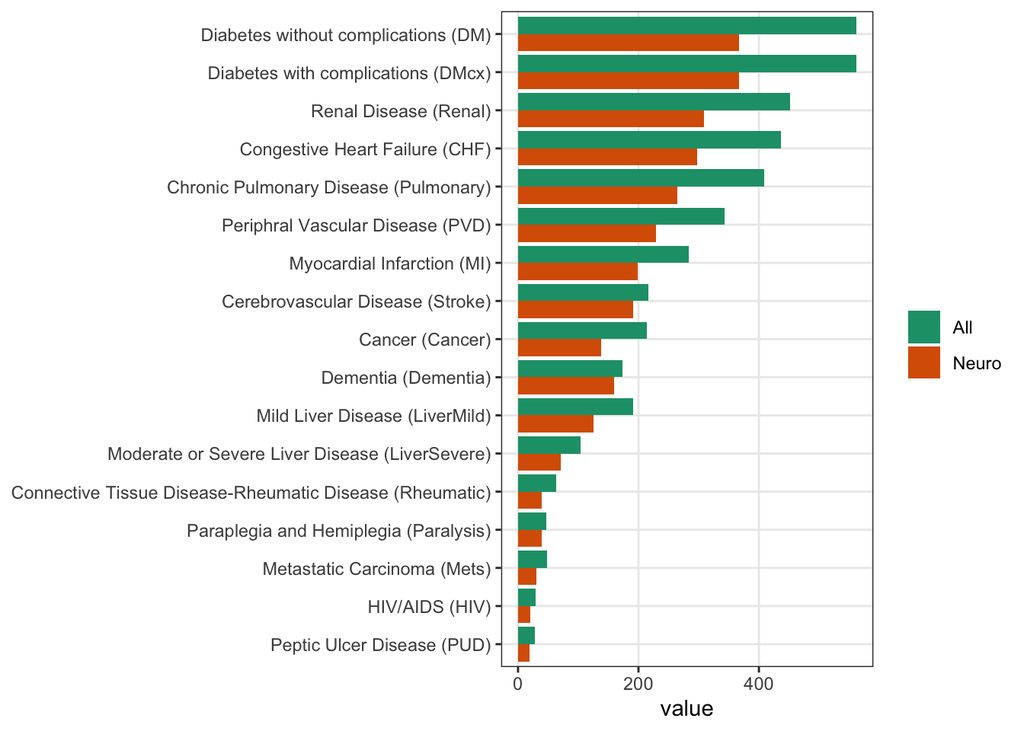

```r
combined_table1 %>%
  pivot_longer(c(n_patients, n_neuro_pats)) %>%
  mutate(fullname = glue::glue('{Comorbidity} ({Abbreviation})'))%>%
  ggplot(aes(x = value, y = fct_reorder(fullname, value), fill = name)) +
  geom_col(position = 'dodge') +
  scale_fill_brewer(palette = 'Dark2', direction = -1,
                    guide = guide_legend(reverse=TRUE),
                    label = c('Neuro', 'All')) +
  labs(y = NULL)
```

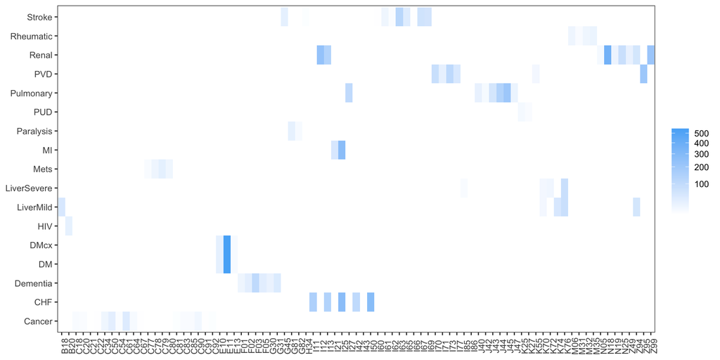

```r
mapped_codes_table %>%
  filter(n_patients > 5) %>%
  ggplot(aes(x = concept_code, y = Abbreviation, fill = n_patients)) +
  geom_tile() +
  scale_fill_gradient(low = 'white', trans = "sqrt") +
  labs(x = NULL, y = NULL) +
  theme(panel.grid = element_blank(),
        axis.text.x = element_text(angle = 90))
```

Here we can determine how many unique patients we have ICD codes for prior to admission:

```r
length(unique(index_scores$patient_num))
```

```
## [1] 1685
```

## Comorbidity matrix

The following code will print the comorbidity matrix with a subset of patients (n)

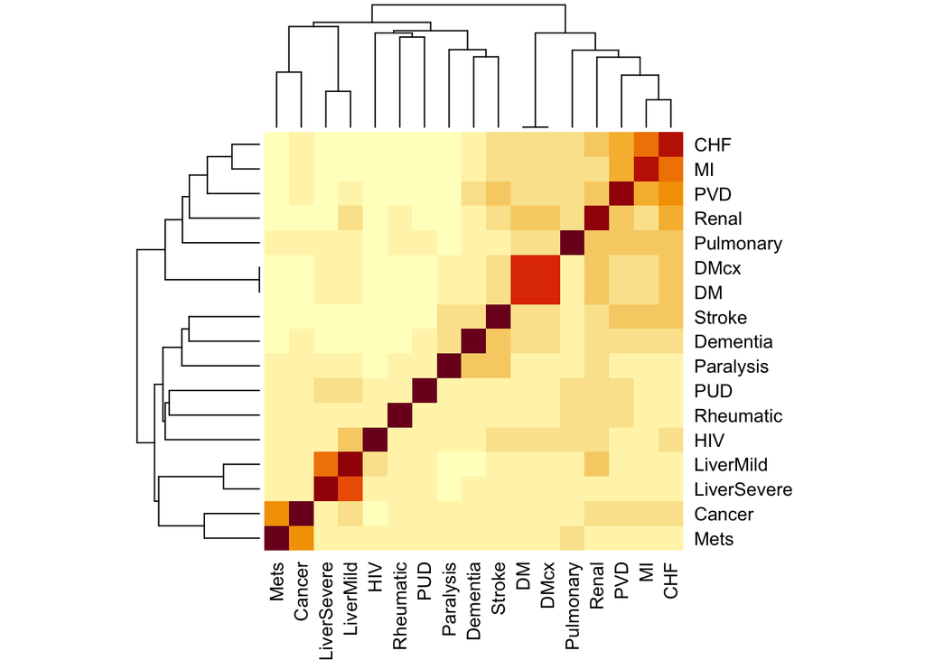

```r
index_scores %>%
  select(MI:HIV) %>%
  cor() %>%
  heatmap()
```

## Charlson scores

### Distribution

The below code will join the comorbidity mappings and the neurological code information, basic demographic and hospital mortality information into one dataframe.

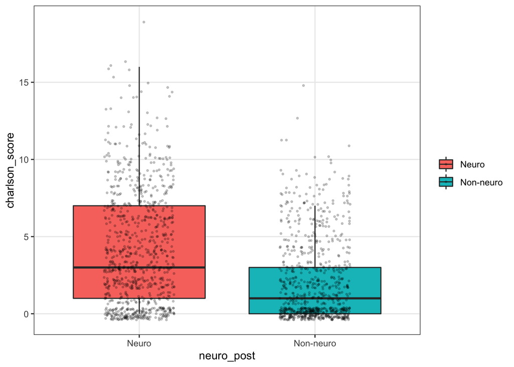

```r
demo_processed$patient_num <- as.character(demo_processed$patient_num)
obs_raw$patient_num <- as.character(obs_raw$patient_num)

scores_unique <- index_scores %>%
  left_join(demo_processed, by = 'patient_num') %>%
  mutate(severe = as.factor(severe) %>%
           fct_recode('Severe' = '1', 'Non-severe' = '0'))

scores_neuro <- obs_raw %>%
  # 1 patient can have different code but each only counted once
  distinct(patient_num, concept_code) %>%
  left_join(neuro_icds_10, by = c('concept_code' = 'icd')) %>%
  left_join(scores_unique, by = 'patient_num') %>%
  filter(!is.na(charlson_score)) %>%
  mutate(concept_code = case_when(
           is.na(`Neurological Disease Category`) ~ 'NN',
           TRUE ~ concept_code) %>%
           as.factor() %>%
           fct_reorder(- charlson_score),
         `Neurological Disease Category` =
           as.factor(`Neurological Disease Category`) %>%
           fct_reorder(charlson_score)) %>%
  {.}

scores_unique %>%
  ggplot(aes(x = neuro_post, y = charlson_score, fill = neuro_post)) +
  geom_boxplot(outlier.colour = NA) +
  geom_jitter(alpha = 0.2, width = 0.2, size = 0.6) +
  NULL
```

### Compared to Quan scoring system

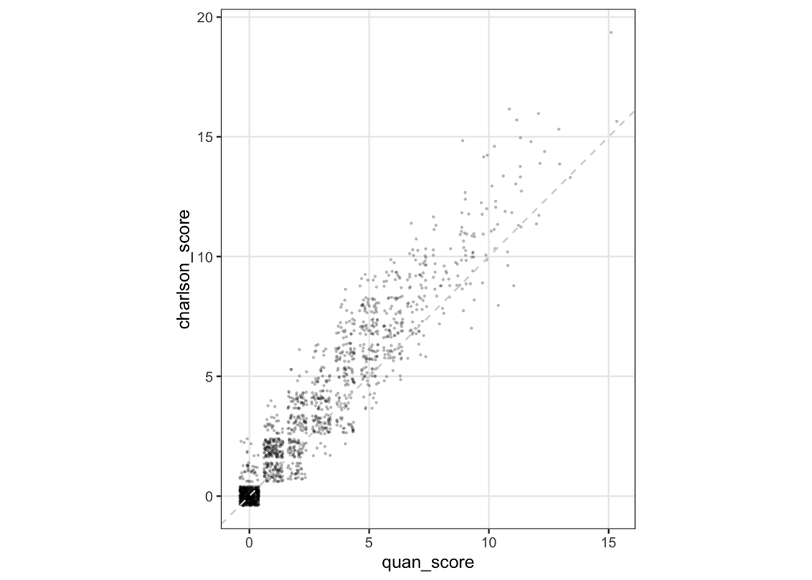

```r
scores_unique %>%
  ggplot(aes(x = quan_score, y = charlson_score)) +
  geom_jitter(alpha = 0.2, size = 0.3) +
  coord_fixed() +
  geom_abline(slope = 1, color = 'lightgrey', linetype = 'dashed')
```

```r
cor(scores_unique$charlson_score, scores_unique$quan_score)
```

```
## [1] 0.9573538
```

### Correlated variables

```r
lm(charlson_score ~ neuro_post + severe + deceased, # + sex + age_group + race,
   data = scores_unique) %>%
  summary()
```

```
##
## Call:
## lm(formula = charlson_score ~ neuro_post + severe + deceased,
##     data = scores_unique)
##
## Residuals:
##     Min      1Q  Median      3Q     Max
## -5.6086 -1.9222 -0.6759  1.6377 14.6377
##
## Coefficients:
##                     Estimate Std. Error t value Pr(>|t|)
## (Intercept)           3.4779     0.1342  25.915  < 2e-16 ***
## neuro_postNon-neuro  -1.8020     0.1587 -11.353  < 2e-16 ***
## severeSevere          0.8844     0.1639   5.397 7.72e-08 ***
## deceased              1.2463     0.2265   5.502 4.34e-08 ***
## ---
## Signif. codes:  0 '***' 0.001 '**' 0.01 '*' 0.05 '.' 0.1 ' ' 1
##
## Residual standard error: 3.168 on 1681 degrees of freedom
## Multiple R-squared:  0.1347, Adjusted R-squared:  0.1332
## F-statistic: 87.24 on 3 and 1681 DF,  p-value: < 2.2e-16
```

### By neuro diagnosis

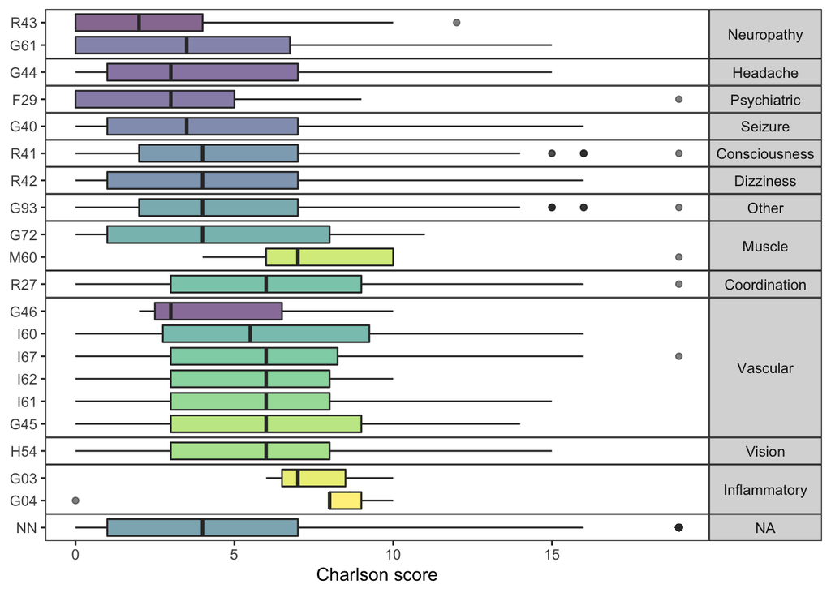

```r
# scores$patient_num <- as.numeric(as.character(scores$patient_num))
scores_neuro %>%
  filter(!is.na(charlson_score)) %>%
  ggplot(aes(y = concept_code, x = charlson_score, fill = concept_code)) +
  facet_grid(rows = vars(`Neurological Disease Category`),
             scales = 'free', space = 'free') +
  geom_boxplot(alpha = 0.6) +
  scale_fill_viridis_d(guide = FALSE, direction = -1) +
  labs(x = 'Charlson score', y = NULL) +
  NULL +
  theme(panel.grid = element_blank(),
        legend.title = element_text(),
        strip.text.y = element_text(angle = 0),
        panel.spacing.x = unit(10, "points"),
        panel.spacing.y = unit(0, "points"))
```

## Neuro condition vs comorbidity type

```r
# Neuro vs non-neuro patients
comorb_long <- scores_unique %>%
  select(patient_num, neuro_post, charlson_score, MI:HIV) %>%
  pivot_longer(MI:HIV) %>%
  filter(value == 1)

comorb_wilcox_func <- function(comorb, df = comorb_long) {
  df <- df %>% filter(name == comorb)
  neuro <- df %>% filter(neuro_post == 'Neuro')
  non_neuro <- df %>% filter(neuro_post == 'Non-neuro')
  wilcox.test(neuro$charlson_score, non_neuro$charlson_score)$p.value
}

comorbs <- comorb_names$Abbreviation

wilcox_res <- comorbs %>%
  sapply(comorb_wilcox_func, df = comorb_long) %>%
  data.frame(p_value = .) %>%
  cbind(comorbs) %>%
  arrange(p_value)
wilcox_res
```

```
##                  p_value     comorbs
## Pulmonary   3.365846e-12   Pulmonary
## PVD         5.028622e-09         PVD
## DM          2.166972e-08          DM
## DMcx        2.166972e-08        DMcx
## CHF         7.359636e-08         CHF
## Renal       7.336067e-07       Renal
## Cancer      1.276125e-06      Cancer
## LiverMild   1.031499e-05   LiverMild
## MI          4.087747e-05          MI
## Mets        2.876573e-04        Mets
## LiverSevere 1.421590e-03 LiverSevere
## HIV         3.898130e-02         HIV
## Paralysis   1.898000e-01   Paralysis
## PUD         2.349855e-01         PUD
## Stroke      3.553671e-01      Stroke
## Rheumatic   4.897224e-01   Rheumatic
## Dementia    7.285158e-01    Dementia
```

```r
median_list <- list()
for (i in comorbs) {
  df <- comorb_long %>% filter(name == i)
  median_list[[i]] <-
    aggregate(charlson_score ~ neuro_post, FUN = "summary", df) %>%
    as.data.frame()
}
median_list = do.call(rbind, median_list)
list_names <- row.names(median_list)

m1 <- median_list[[1]]
m2 <- median_list[[2]]
median_list <- cbind(m1, m2)
row.names(median_list) <- list_names
colnames(median_list)[1] <- "Neuro"
median_list
```

```
##               Neuro       Min. 1st Qu. Median Mean               3rd Qu. Max.
## MI.1          "Neuro"     "2"  "6"     "8"    "7.73366834170854" "10"    "19"
## MI.2          "Non-neuro" "2"  "4"     "6"    "6.14117647058824" "8"     "15"
## CHF.1         "Neuro"     "1"  "5"     "7"    "7.35234899328859" "9"     "19"
## CHF.2         "Non-neuro" "1"  "3.25"  "6"    "5.58695652173913" "7"     "15"
## PVD.1         "Neuro"     "1"  "5"     "7"    "7.54148471615721" "10"    "19"
## PVD.2         "Non-neuro" "1"  "3"     "5"    "5.2719298245614"  "7.75"  "15"
## Stroke.1      "Neuro"     "1"  "4"     "7"    "7.15706806282722" "10"    "19"
## Stroke.2      "Non-neuro" "1"  "2"     "7"    "6.32"             "9"     "15"
## Dementia.1    "Neuro"     "1"  "3"     "6"    "6.2"              "9"     "19"
## Dementia.2    "Non-neuro" "1"  "3"     "6"    "5.69230769230769" "7"     "11"
## Pulmonary.1   "Neuro"     "1"  "4"     "7"    "6.74339622641509" "9"     "19"
## Pulmonary.2   "Non-neuro" "1"  "1"     "3"    "4.13888888888889" "7"     "15"
## Rheumatic.1   "Neuro"     "1"  "4"     "6"    "6.30769230769231" "8.5"   "14"
## Rheumatic.2   "Non-neuro" "1"  "3.75"  "6"    "5.625"            "8"     "11"
## PUD.1         "Neuro"     "1"  "5.5"   "8"    "7.84210526315789" "10"    "16"
## PUD.2         "Non-neuro" "1"  "6"     "7"    "6.33333333333333" "8"     "9"
## LiverMild.1   "Neuro"     "1"  "5"     "8"    "7.88888888888889" "10"    "19"
## LiverMild.2   "Non-neuro" "1"  "3"     "5"    "5.58461538461538" "8"     "13"
## DM.1          "Neuro"     "2"  "4"     "6"    "6.4141689373297"  "9"     "19"
## DM.2          "Non-neuro" "2"  "2"     "4"    "4.8"              "7"     "15"
## DMcx.1        "Neuro"     "2"  "4"     "6"    "6.4141689373297"  "9"     "19"
## DMcx.2        "Non-neuro" "2"  "2"     "4"    "4.8"              "7"     "15"
## Paralysis.1   "Neuro"     "2"  "6"     "8"    "7.82051282051282" "10"    "15"
## Paralysis.2   "Non-neuro" "2"  "4.75"  "5.5"  "6.25"             "8.25"  "11"
## Renal.1       "Neuro"     "2"  "5"     "7"    "7.29773462783171" "9"     "19"
## Renal.2       "Non-neuro" "2"  "4"     "6"    "5.72727272727273" "7"     "15"
## Cancer.1      "Neuro"     "2"  "5"     "8"    "7.72463768115942" "10"    "16"
## Cancer.2      "Non-neuro" "2"  "2.75"  "6"    "5.31578947368421" "7"     "13"
## LiverSevere.1 "Neuro"     "3"  "5"     "8"    "8.2112676056338"  "10"    "19"
## LiverSevere.2 "Non-neuro" "3"  "3"     "5"    "5.90909090909091" "9"     "13"
## Mets.1        "Neuro"     "6"  "9"     "11"   "10.7666666666667" "12.75" "16"
## Mets.2        "Non-neuro" "6"  "6"     "7.5"  "7.66666666666667" "8"     "13"
## HIV.1         "Neuro"     "7"  "8.75"  "12.5" "11.8"             "15"    "19"
## HIV.2         "Non-neuro" "6"  "7"     "8"    "8.66666666666667" "9"     "15"
```

Q: Do we need `median_list`?

## Evaluating Timeframe of Comorbidities

Qs: When are these comorbidities getting mapped. Understanding ICD code assignnment can help us prevent confusing complications with comorbidities and vice versa.

It would be helpful to review the literature as well, what did the original developers of the comorbidity indexes do? How were they validated?

```r
# maps codes that occurred anytime 356 days prior to COVID admission
comorb365 <- map_charlson_codes(obs_raw, comorb_names, -365, -1)
# maps codes that occurred at least 15 days to a year prior to admission
comorb365_15 <- map_charlson_codes(obs_raw, comorb_names, -365, -15)
# maps codes that occurred at least 14 days to 1 day prior to admission
comorb14_1 <- map_charlson_codes(obs_raw, comorb_names, -14, -1)
# map only day of admission
comorb_dayOf <- map_charlson_codes(obs_raw, comorb_names, 0, 0)
# consider codes only codes after admission
comorb_After <- map_charlson_codes(obs_raw, comorb_names, 1, 1000)

## Abstract individual index_scores and compute table1
# time_frame is text to provide a label that will indicate the timeframe of comorb mapping
comorb365 <- process_tables(comorb365, "1 to 365 days prior admission")
comorb365_15 <- process_tables(comorb365_15, "15 to 365 days prior admission")
comorb14_1 <- process_tables(comorb14_1, "14 to 1 days prior admission")
comorb_dayOf <- process_tables(comorb_dayOf, "Only Day of Admission")
comorb_After <- process_tables(comorb_After, "Any Day After Admission")

all_tables <- rbind(comorb365, comorb365_15, comorb14_1, comorb_dayOf, comorb_After)
```

### Timeline - All Patients

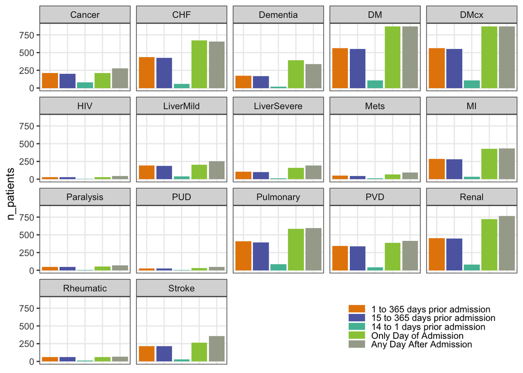

```r
all_tables$time_map <- factor(
  all_tables$time_map,
  levels = c(
    "1 to 365 days prior admission",
    "15 to 365 days prior admission",
    "14 to 1 days prior admission",
    "Only Day of Admission",
    "Any Day After Admission"
  )
)


ggplot(all_tables, aes(x = time_map,  y = n_patients, fill = time_map)) +
  geom_bar(stat = "identity") +
  facet_wrap( ~ Abbreviation) +
  scale_fill_carto_d() +
  theme(
    legend.position = c(0.8, 0.12),
    legend.key.height = unit(3, 'mm'),
    axis.title.x = element_blank(),
    axis.text.x = element_blank(),
    axis.ticks.x = element_blank()
  )
```

## First occurence of a comorbidity

The below figure plots the first time a patient had an ICD code map to that specific comorbidity.

Perhaps could go a conservative route and only include comorbidities if there was a previous record of it? However, each comorbidity category can contain multiple different types of diseases. So perhaps could be problematic.

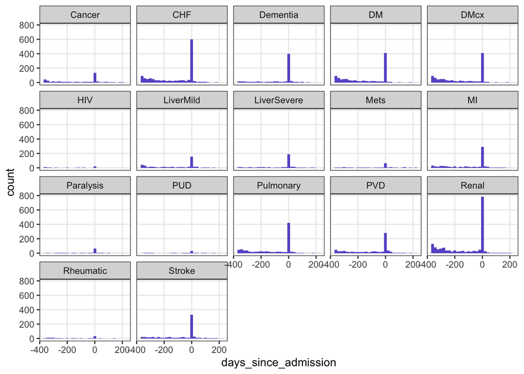

```r
obs_first <- obs_raw %>%
  group_by(patient_num) %>%
  merge(mapped_codes_table, by = "concept_code") %>%
  arrange(days_since_admission) %>%
  group_by(patient_num, Abbreviation) %>%
  mutate(first_occurence = min(days_since_admission),
         first_occurence_indicator = if_else(first_occurence == days_since_admission, 1, 0)) %>%
  ungroup()  %>%
  filter(first_occurence_indicator == 1)

ggplot(obs_first, aes(x = days_since_admission)) +
  geom_histogram(fill = 'slateblue') +
   facet_wrap(~Abbreviation)
```

## Neuro Patients timeline of first neuro diagnosis

If this is helpful, we may want to move to the explore-neuro.rmd file.

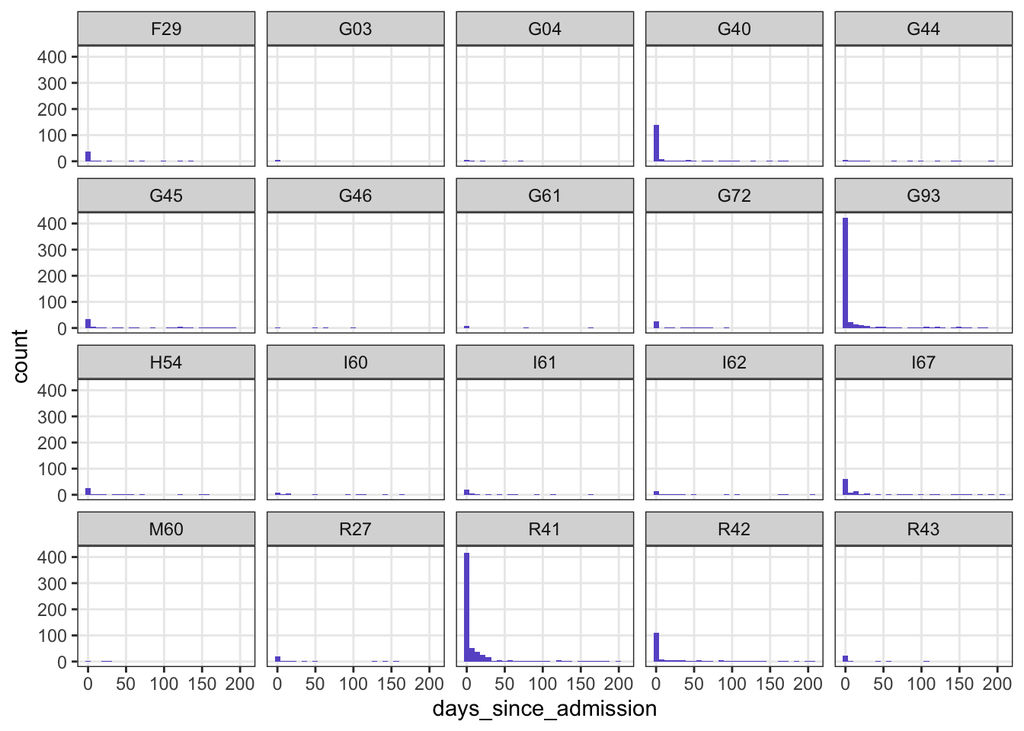

```r
post_adm_neuro_pats <- obs_raw %>%
  filter(days_since_admission >= 0) %>%
  right_join(neuro_icds_10, by = c('concept_code' = 'icd')) %>%
  group_by(patient_num, concept_code) %>%
  mutate(first_occurence = min(days_since_admission),
         first_occurence_indicator = if_else(first_occurence == days_since_admission, 1, 0)) %>%
  ungroup()  %>%
  filter(first_occurence_indicator == 1)

ggplot(post_adm_neuro_pats, aes(x = days_since_admission)) +
  geom_histogram(fill = 'slateblue') +
   facet_wrap(~concept_code)
```

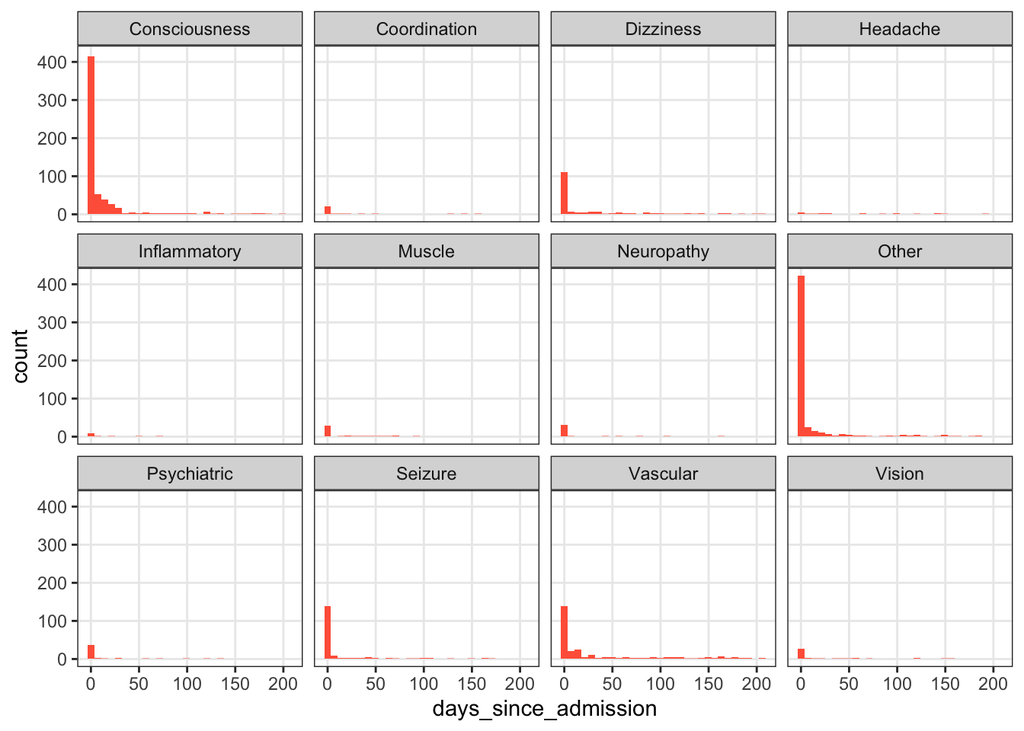

```r
ggplot(post_adm_neuro_pats, aes(x = days_since_admission)) +
  geom_histogram(fill = 'tomato') +
   facet_wrap(~`Neurological Disease Category`)
```

## Additional Notes:

Neuro Codes: G04, G45, G46, I60, 161, 162, and 167 will map to comorbidities. An important consideration is that we don’t want to confuse comorbidities for complications of hospital stay/COVID-19

The below will assess how many on these neuro comorbidity codes occurred on the day of admission and how many neuro codes in general are on the day of admission.

*Note: This is just for data exploration right now, we are going to initially just assume that any codes prior to the COVID-19 admission are comorbidities*

```r
neuro_comorb_codes <- c("G04", "G45", "G46",  # paralysis codes
                        "I60", "161", "162", "167") # stroke codes

neuro_comorb_on_admission <- obs_raw %>%
  filter(days_since_admission == 0) %>%
  filter(concept_code %in% neuro_comorb_codes) %>%
  select(patient_num, concept_code) %>%
  distinct()
unique(neuro_comorb_on_admission$concept_code)
```

```
## [1] "I60" "G45" "G04" "G46"
```